# H04 Stage 2: implementation, diagnostics, and V0 comparison

Nature Health analysis audit — author result and Stage 2 gate

Published

August 11, 2026

## 1 Scope and Stage 2 answer

The preregistered hypothesis is:

> **H4: Hourly self-reported activity categories predict hourly geometric mean melanopic EDI.**

This report implements the author-approved repair. It does not treat the activity labels as mutually exclusive behavioural states and does not estimate causal effects. Each estimate is the average melEDI associated with a reported collapsed activity category after sharing a multi-select participant-hour’s contribution equally across its retained categories.

**ImportantStage 2 result gate**

The primary near-eye robust equality test rejects equality of the five interpretable activity categories, $F_{4,125} =$ 83.59, with **raw p < 0.001** under the prespecified 0.05 omnibus decision rule. The estimates show large, precisely estimated differences in magnitude, but the conclusion is an observational association: reported activity category is associated with one-hour zero-aware geometric mean melEDI. Chest evidence is complementary and points in the same broad direction. Other/unspecified activity remains fitted but supports no scientific claim.

Both exploratory temporal models pass their construction and added-context gates. Following the author’s 2026-08-11 amendment, their ribbons use the same uncertainty implementation as H03: model-based pointwise 95% intervals from the accepted GAMM’s fitted-coefficient covariance. They are not simultaneous bands and support no curve-wide significance claim. No bootstrap or simulation enters the reported temporal results.

No H03 result or significance classification was transferred. H03 supplied the population-mean architecture; all H04 support, coefficients, restrictions, intervals, diagnostics, and classifications were recomputed from H04 inputs.

## 2 Fixed representation and exact fitted samples

The three outdoor flags—active travel, outdoor work, and outdoor free time—were collapsed before pivoting. Duplicate collapsed labels were removed within an hour. Co-selected Other was then suppressed in favour of named categories; Other was retained only when it was the sole selection. A fitted hour with $k$ retained distinct labels generated $k$ long rows, each with prior weight $1/k$. Hours with no selected category are not “no activity”; they were kept out of the category model and remain visible in sample flow. No diary free text was inspected or recoded.

Table 1: Exact primary sample flow; hours lacking a retained category are accounted for but are not modelled as no activity.

Primary sample flow

Near-eye is primary; chest is complementary

| Placement | Outcome-grid hours | Outcome-available hours | No eligible diary key | No retained activity | Participants | Participant-days | Unique fitted hours | Generated long rows | Effective weighted hours |
| --- | --- | --- | --- | --- | --- | --- | --- | --- | --- |
| Near-eye | 19,584 | 18,953 | 481 | 1,946 | 126 | 724 | 16,526 | 17,266 | 16,526 |
| Chest | 21,648 | 21,004 | 585 | 291 | 150 | 875 | 20,128 | 21,071 | 20,128 |

The near-eye model contains 126 participants, 724 participant-days, 16,526 unique participant-hours, 17,266 long rows, and 16,526 effective weighted hours. The chest model contains 150 participants, 875 participant-days, 20,128 unique participant-hours, 21,071 long rows, and 20,128 effective weighted hours.

Table 2: Number of retained distinct activity labels per fitted participant-hour.

Distribution of k

Each long row receives weight 1/k

| Placement | k | Unique participant-hours | Participants | Participant-days | Percent of fitted hours |
| --- | --- | --- | --- | --- | --- |
| Near-eye | 1 | 15,810 | 126 | 724 | 95.7 |
| Near-eye | 2 | 692 | 65 | 252 | 4.2 |
| Near-eye | 3 | 24 | 8 | 18 | 0.1 |
| Chest | 1 | 19,210 | 150 | 875 | 95.4 |
| Chest | 2 | 893 | 82 | 331 | 4.4 |
| Chest | 3 | 25 | 8 | 19 | 0.1 |

Table 3: Observed category support and weighted totals in the exact fitted samples.

Category support

Weighted hours need not equal long rows when categories were co-selected

| Placement | Category | Unique hours | Long rows | Weighted hours | Participants | Participant-days | Sites |
| --- | --- | --- | --- | --- | --- | --- | --- |
| Near-eye | Sleeping | 5,906 | 5,906 | 5,819.7 | 126 | 714 | 9 |
| Near-eye | At home | 5,105 | 5,105 | 4,889.2 | 126 | 709 | 9 |
| Near-eye | On the road with public transport/car | 818 | 818 | 679.5 | 111 | 369 | 9 |
| Near-eye | Working in the office/from home | 3,624 | 3,624 | 3,498.0 | 124 | 511 | 9 |
| Near-eye | Outdoors | 1,422 | 1,422 | 1,248.7 | 121 | 480 | 9 |
| Near-eye | Other/unspecified activity | 391 | 391 | 391.0 | 72 | 159 | 9 |
| Chest | Sleeping | 7,155 | 7,155 | 7,039.7 | 150 | 868 | 8 |
| Chest | At home | 6,170 | 6,170 | 5,887.0 | 150 | 859 | 8 |
| Chest | On the road with public transport/car | 1,056 | 1,056 | 892.0 | 135 | 460 | 8 |
| Chest | Working in the office/from home | 4,403 | 4,403 | 4,242.8 | 148 | 609 | 8 |
| Chest | Outdoors | 1,656 | 1,656 | 1,435.5 | 143 | 553 | 8 |
| Chest | Other/unspecified activity | 631 | 631 | 631.0 | 94 | 232 | 8 |

Table 4: Site-level support and weighted totals in the exact fitted samples.

Site support

Sites follow submitted-manuscript names and order

| Placement | Site | Participants | Participant-days | Unique hours | Long rows | Weighted hours |
| --- | --- | --- | --- | --- | --- | --- |
| Near-eye | Borås (SE) | 13 | 78 | 1,815 | 2,010 | 1,815.0 |
| Near-eye | Delft (NL) | 13 | 76 | 1,636 | 1,751 | 1,636.0 |
| Near-eye | Dortmund (DE) | 18 | 104 | 2,372 | 2,467 | 2,372.0 |
| Near-eye | Tübingen (DE) | 13 | 77 | 1,764 | 1,803 | 1,764.0 |
| Near-eye | Munich (DE) | 10 | 60 | 1,390 | 1,402 | 1,390.0 |
| Near-eye | Madrid (ES) | 22 | 121 | 2,731 | 2,800 | 2,731.0 |
| Near-eye | Izmir (TR) | 16 | 95 | 2,215 | 2,365 | 2,215.0 |
| Near-eye | San José (CR) | 6 | 32 | 740 | 805 | 740.0 |
| Near-eye | Kumasi (GH) | 15 | 81 | 1,863 | 1,863 | 1,863.0 |
| Chest | Borås (SE) | 16 | 96 | 2,243 | 2,486 | 2,243.0 |
| Chest | Delft (NL) | 15 | 91 | 1,991 | 2,156 | 1,991.0 |
| Chest | Dortmund (DE) | 19 | 108 | 2,500 | 2,595 | 2,500.0 |
| Chest | Munich (DE) | 10 | 60 | 1,390 | 1,402 | 1,390.0 |
| Chest | Madrid (ES) | 21 | 116 | 2,645 | 2,714 | 2,645.0 |
| Chest | Izmir (TR) | 16 | 96 | 2,238 | 2,392 | 2,238.0 |
| Chest | San José (CR) | 38 | 224 | 5,188 | 5,393 | 5,188.0 |
| Chest | Kumasi (GH) | 15 | 84 | 1,933 | 1,933 | 1,933.0 |

Site-level weighted totals are retained in `artifacts/06_model_data/H04/H04_weighted_support_totals.csv`, and complete site-by-category support is retained in `artifacts/06_model_data/H04/H04_site_category_support.csv`. KNUST × Other/unspecified activity remains observed in the additive primary frame but is support-inadequate for a cell-specific heterogeneity estimate; no such term was forced into the separate heterogeneity companion.

## 3 Exact implemented models

### 3.1 Wilkinson formulas supplied to the fitters

The following cell is evaluated during rendering but fits no model. It reconstructs every fitted or prespecified fallback formula and verifies the literal formula text against the durable Stage 2 registry.

```r
implemented_formulas <- list(
  primary_full = geo_medi_1h ~ site + activity,
  primary_five_named_null = geo_medi_1h ~ site + other_indicator,
  secondary_six_category_null = geo_medi_1h ~ site,
  heterogeneity_five_named_full = geo_medi_1h ~ site * activity_named,
  heterogeneity_five_named_additive = geo_medi_1h ~ site + activity_named,
  heterogeneity_core_full = geo_medi_1h ~ site * activity_core,
  heterogeneity_core_additive = geo_medi_1h ~ site + activity_core,
  v0_full = geo_medi_1h ~ site * activity_v0 + (1 | Id),
  v0_site_only = geo_medi_1h ~ site + (1 | Id),
  temporal_no_activity = stats::as.formula(paste0(
    "geo_medi_1h ~ s(time_hour, bs = 'cc', k = 12) + ",
    "s(time_hour, site, bs = 'sz', k = 12) + ",
    "s(time_hour, participant, bs = 'fs', k = 10) + ",
    "s(participant_day, bs = 're')"
  )),
  temporal_activity_long = stats::as.formula(paste0(
    "geo_medi_1h ~ s(time_hour, bs = 'cc', k = 12) + ",
    "s(time_hour, activity, bs = 'sz', k = 12) + ",
    "s(time_hour, site, bs = 'sz', k = 12) + ",
    "s(time_hour, participant, bs = 'fs', k = 10) + ",
    "s(participant_day, bs = 're')"
  ))
)

formula_text <- function(formula) {
  paste(deparse(formula, width.cutoff = 500L), collapse = " ")
}
implemented_formula_registry <- enframe(
  implemented_formulas,
  name = "formula_id",
  value = "formula"
) |>
  mutate(formula = vapply(.data$formula, formula_text, character(1)))

stopifnot(
  identical(implemented_formula_registry$formula_id, formulas$formula_id),
  identical(
    gsub("'", "\"", implemented_formula_registry$formula, fixed = TRUE),
    formulas$formula
  )
)

implemented_formula_registry |>
  audit_gt("Implemented formula registry") |>
  cols_width(formula_id ~ pct(25), formula ~ pct(75))
```

Table 5: Exact Wilkinson formulas supplied to H04 fitting functions.

Implemented formula registry

| formula_id | formula |
| --- | --- |
| primary_full | geo_medi_1h ~ site + activity |
| primary_five_named_null | geo_medi_1h ~ site + other_indicator |
| secondary_six_category_null | geo_medi_1h ~ site |
| heterogeneity_five_named_full | geo_medi_1h ~ site * activity_named |
| heterogeneity_five_named_additive | geo_medi_1h ~ site + activity_named |
| heterogeneity_core_full | geo_medi_1h ~ site * activity_core |
| heterogeneity_core_additive | geo_medi_1h ~ site + activity_core |
| v0_full | geo_medi_1h ~ site * activity_v0 + (1 \| Id) |
| v0_site_only | geo_medi_1h ~ site + (1 \| Id) |
| temporal_no_activity | geo_medi_1h ~ s(time_hour, bs = "cc", k = 12) + s(time_hour, site, bs = "sz", k = 12) + s(time_hour, participant, bs = "fs", k = 10) + s(participant_day, bs = "re") |
| temporal_activity_long | geo_medi_1h ~ s(time_hour, bs = "cc", k = 12) + s(time_hour, activity, bs = "sz", k = 12) + s(time_hour, site, bs = "sz", k = 12) + s(time_hour, participant, bs = "fs", k = 10) + s(participant_day, bs… |

The following evaluated expressions record the exact calls without executing another fit inside the report. The archived model objects assert the same formula text.

```r
model_call_registry <- list(
  primary_quasi_tweedie = quote(stats::glm(
    formula = implemented_formulas$primary_full,
    data = model_frame,
    family = statmod::tweedie(var.power = 1.539919, link.power = 0),
    weights = analysis_weight,
    control = stats::glm.control(epsilon = 1e-10, maxit = 100L),
    model = TRUE,
    x = TRUE,
    y = TRUE
  )),
  participant_cluster_hc1 = quote(sandwich::vcovCL(
    fitted_primary_model,
    cluster = model_frame$participant,
    type = "HC1",
    cadjust = TRUE,
    fix = FALSE
  )),
  v0_bridge = quote(glmmTMB::glmmTMB(
    formula = implemented_formulas$v0_full,
    data = v0_frame,
    family = glmmTMB::tweedie(link = "log"),
    REML = FALSE,
    contrasts = list(
      site = stats::contr.sum,
      activity_v0 = stats::contr.treatment
    )
  )),
  temporal_preliminary = quote(mgcv::bam(
    formula = implemented_formulas$temporal_activity_long,
    data = temporal_frame,
    family = mgcv::Tweedie(p = 1.539919, link = "log"),
    weights = analysis_weight,
    method = "fREML",
    discrete = TRUE,
    rho = 0,
    AR.start = temporal_frame$AR_start,
    knots = list(time_hour = c(0, 24)),
    nthreads = 1L,
    gc.level = 1L,
    drop.unused.levels = TRUE
  )),
  temporal_final = quote(mgcv::bam(
    formula = implemented_formulas$temporal_activity_long,
    data = temporal_frame,
    family = mgcv::Tweedie(p = 1.539919, link = "log"),
    weights = analysis_weight,
    method = "fREML",
    discrete = TRUE,
    rho = estimated_rho,
    AR.start = temporal_frame$AR_start,
    knots = list(time_hour = c(0, 24)),
    nthreads = 1L,
    gc.level = 1L,
    drop.unused.levels = TRUE
  ))
)

enframe(model_call_registry, name = "model", value = "call") |>
  mutate(call = vapply(.data$call, function(x) {
    paste(deparse(x, width.cutoff = 500L), collapse = " ")
  }, character(1))) |>
  audit_gt("Implemented model calls") |>
  cols_width(model ~ pct(22), call ~ pct(78))
```

Table 6: Exact fitting calls used by the Stage 2 implementation; expressions are displayed, not re-fitted.

Implemented model calls

| model | call |
| --- | --- |
| primary_quasi_tweedie | stats::glm(formula = implemented_formulas$primary_full, data = model_frame, family = statmod::tweedie(var.power = 1.539919, link.power = 0), weights = analysis_weight, control = stats::glm.control(eps… |
| participant_cluster_hc1 | sandwich::vcovCL(fitted_primary_model, cluster = model_frame$participant, type = "HC1", cadjust = TRUE, fix = FALSE) |
| v0_bridge | glmmTMB::glmmTMB(formula = implemented_formulas$v0_full, data = v0_frame, family = glmmTMB::tweedie(link = "log"), REML = FALSE, contrasts = list(site = stats::contr.sum, activity_v0 = stats::contr.tr… |
| temporal_preliminary | mgcv::bam(formula = implemented_formulas$temporal_activity_long, data = temporal_frame, family = mgcv::Tweedie(p = 1.539919, link = "log"), weights = analysis_weight, method = "fREML", discrete = TRUE… |
| temporal_final | mgcv::bam(formula = implemented_formulas$temporal_activity_long, data = temporal_frame, family = mgcv::Tweedie(p = 1.539919, link = "log"), weights = analysis_weight, method = "fREML", discrete = TRUE… |

### 3.2 Mean model, weights, and inference

The primary and complementary mean models use a quasi-Tweedie variance power of 1.539919 and log link. The prior weight is the exact `analysis_weight = 1/k`. The same site-prefixed participant cluster contains concurrent category rows from an hour and all longitudinal rows from that participant. The covariance is participant-clustered HC1 with cluster adjustment and no positive-definite repair. Intervals use $t_{G-1}$; robust joint tests use $F_{q,G-1}$, where $G$ is the exact number of participant clusters.

For the primary five-category test, the unrestricted six-category model is unchanged. If $R$ is the four-row restriction matrix that compares Sleeping, vehicle/public-transport travel, indoor/home working, and Outdoors with At home, then

$$F = \frac{
(R\widehat{\boldsymbol{\beta}})^\mathsf{T}
(R V_{\mathrm{HC1}} R^\mathsf{T})^{-1}
(R\widehat{\boldsymbol{\beta}})
}{4},
\qquad F \sim F_{4,G-1}.$$

Every Other/unspecified coefficient in $R$ is zero. The secondary five-row restriction adds Other versus At home and is reported only as `H04-F1b`.

Equal-site category means average site-specific fitted log means with weight $1/S$ and back-transform once:

$$\bar{\eta}_c = \frac{1}{S}\sum_{s=1}^{S}
x_{sc}^{\mathsf{T}}\widehat{\boldsymbol{\beta}},
\qquad
\bar{\mu}_c = \exp\!\left(\bar{\eta}_c\right).$$

Thus $\bar{\mu}_c$ is the geometric mean of the site-specific fitted means, not their response-scale arithmetic mean.

## 4 Primary near-eye and complementary chest results

Table 7: Equal-site standardized activity-category estimates with participant-cluster robust 95% confidence intervals.

Activity-associated melEDI

At home is the reference; H04-F2 decisions use BH-adjusted p; Other is display-only

| Placement | Category | Mean melEDI lx (95% CI) | Ratio vs At home (95% CI) | Difference, lx (95% CI) | Raw p | BH-adjusted p | Role |
| --- | --- | --- | --- | --- | --- | --- | --- |
| Near-eye | Sleeping | 7.0 (4.1 to 11.7) | 0.093 (0.058 to 0.150) | -67.7 (-82.7 to -52.8) | <0.001 | **<0.001** | H04-F2 |
| Near-eye | At home | 74.7 (60.3 to 92.5) | 1.000 (1.000 to 1.000) | 0.0 (0.0 to 0.0) | — | — | Reference |
| Near-eye | On the road with public transport/car | 332.1 (263.9 to 417.9) | 4.446 (3.218 to 6.144) | 257.4 (178.5 to 336.3) | <0.001 | **<0.001** | H04-F2 |
| Near-eye | Working in the office/from home | 202.0 (177.1 to 230.5) | 2.705 (2.190 to 3.342) | 127.4 (101.2 to 153.5) | <0.001 | **<0.001** | H04-F2 |
| Near-eye | Outdoors | 864.8 (678.0 to 1103.0) | 11.578 (8.418 to 15.924) | 790.1 (579.6 to 1000.6) | <0.001 | **<0.001** | H04-F2 |
| Near-eye | Other/unspecified activity | 221.8 (97.2 to 506.4) | 2.970 (1.228 to 7.182) | 147.1 (-39.0 to 333.3) | — | — | Display only; no claim |
| Chest | Sleeping | 7.7 (4.2 to 14.2) | 0.088 (0.049 to 0.157) | -79.9 (-97.3 to -62.5) | <0.001 | **<0.001** | H04-F2 |
| Chest | At home | 87.6 (71.0 to 108.0) | 1.000 (1.000 to 1.000) | 0.0 (0.0 to 0.0) | — | — | Reference |
| Chest | On the road with public transport/car | 575.9 (446.0 to 743.5) | 6.577 (4.822 to 8.970) | 488.3 (342.2 to 634.4) | <0.001 | **<0.001** | H04-F2 |
| Chest | Working in the office/from home | 210.0 (184.0 to 239.8) | 2.399 (1.903 to 3.024) | 122.5 (91.4 to 153.6) | <0.001 | **<0.001** | H04-F2 |
| Chest | Outdoors | 1203.0 (938.8 to 1541.6) | 13.739 (10.026 to 18.826) | 1115.5 (817.7 to 1413.2) | <0.001 | **<0.001** | H04-F2 |
| Chest | Other/unspecified activity | 315.7 (173.4 to 574.7) | 3.605 (1.890 to 6.878) | 228.1 (37.1 to 419.2) | — | — | Display only; no claim |

Near eye, the equal-site standardized mean was 74.7 lx at home, 7.0 lx while sleeping, 332.1 lx during vehicle/public-transport travel, 202.0 lx during indoor/home working, and 864.8 lx outdoors. Relative to At home, the named ratios were 0.093, 4.446, 2.705, and 11.578, respectively. Chest estimates were 7.7, 87.6, 575.9, 210.0, and 1,203.0 lx in the same display order. These are average associations with reported categories, not transitions, individual effects, or causal contrasts.

Table 8: Primary five-named-category and secondary six-category robust omnibus tests.

Robust category tests

Finite-cluster F inference; alpha = 0.05

| Placement | Family | Test | Restrictions | F statistic | Numerator df | Denominator df | Raw p | Status |
| --- | --- | --- | --- | --- | --- | --- | --- | --- |
| Near-eye | H04-F1 | Five named categories; Other unrestricted | 4 | 83.59 | 4 | 125 | **<0.001** | ESTIMABLE |
| Near-eye | H04-F1b | All six categories (secondary) | 5 | 66.96 | 5 | 125 | **<0.001** | ESTIMABLE |
| Chest | H04-F1 | Five named categories; Other unrestricted | 4 | 93.31 | 4 | 149 | **<0.001** | ESTIMABLE |
| Chest | H04-F1b | All six categories (secondary) | 5 | 75.62 | 5 | 149 | **<0.001** | ESTIMABLE |

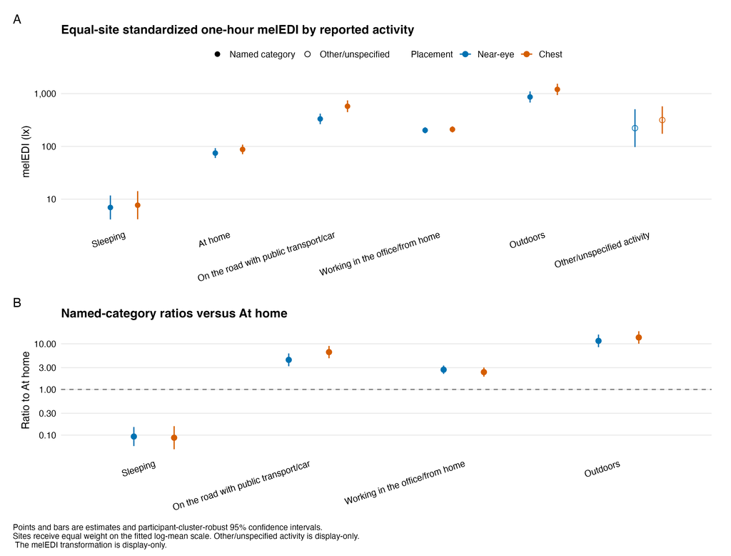

Figure 1: Equal-site standardized mean melEDI and named-category ratios versus At home.

## 5 Separate site heterogeneity

The additive primary model was not replaced by an interaction. The separate heterogeneity analysis excluded Other and tested only observed named-category support. Both placements passed the results-blind covariance and influence gate for the full five-named-category architecture; the four-category core fallback was therefore not selected.

Table 9: Support-gated site heterogeneity and robust omnibus tests.

Five-named-category site heterogeneity

Exploratory H04-F3; Other is excluded

| Placement | Architecture | Restrictions | F statistic | Denominator df | Raw p | Covariance condition | Max score share | Max leverage share | Gate pass |
| --- | --- | --- | --- | --- | --- | --- | --- | --- | --- |
| Near-eye | five_named | 32 | 8.03 | 125 | **<0.001** | 126.86 | 0.459 | 0.024 | TRUE |
| Chest | five_named | 28 | 11.62 | 149 | **<0.001** | 106.82 | 0.171 | 0.017 | TRUE |

Table 10: Complete support-gated H04-F4 family accounting.

Site-deviation multiplicity accounting

One complete BH family per placement; adjusted alpha = 0.050

| Placement | H04-F4 members | BH significant | Other supported members | Support non-estimable | Other-category rows excluded |
| --- | --- | --- | --- | --- | --- |
| Near-eye | 44 | 17 | 27 | 1 | 9 |
| Chest | 40 | 9 | 31 | 0 | 8 |

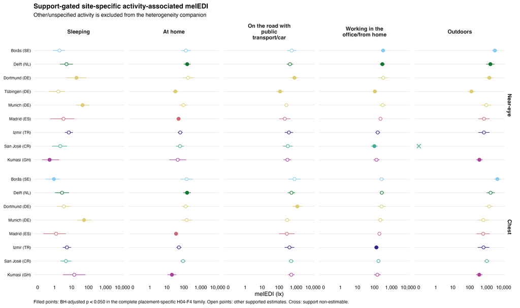

Figure 2: Observed site-specific activity estimates and the complete support-gated H04-F4 decisions from the accepted heterogeneity companion.

This is evidence that activity-associated means vary among sites, not a basis for selecting or ranking individual sites post hoc. The complete H04-F4 vector contains 44 near-eye and 40 chest support-eligible deviations; 17 and 9, respectively, pass the labelled BH-adjusted 0.050 rule. All raw and adjusted p-values are retained in `H04_site_activity_estimands.csv` and the paired figure-source CSV. Unsupported cells are labelled non-estimable rather than filled or pooled.

## 6 Diagnostics and acceptability

Table 11: Predeclared diagnostic assessments with plain-language interpretation.

Primary mean-model diagnostics

Acceptability applies to the stated population-average estimand

| Placement | Diagnostic | Evidence | Assessment | Interpretation |
| --- | --- | --- | --- | --- |
| Near-eye | Fractional-weight integrity | 16526 hours checked; maximum \|sum(weight)-1\| = 0; rows equal k: TRUE | ACCEPTABLE | Each participant-hour contributes one total unit across retained categories. |
| Near-eye | IRLS, design, and robust covariance | converged=TRUE; rank=14/14; covariance finite=TRUE; H04-F1 status=ESTIMABLE | ACCEPTABLE | The fitted mean and registered robust restriction are numerically estimable. |
| Near-eye | Participant-cluster influence | maximum score share=0.398; maximum leverage share=0.016 | ACCEPTABLE | No participant exceeds the predeclared architecture-gate influence limits. |
| Near-eye | Mean-variance and calibration | hour residual-fitted Spearman=-0.310; absolute-residual Spearman=0.483 | ACCEPTABLE WITH LIMITATION | The quasi mean model is used for robust population-average inference; remaining variance-pattern structure is visible in calibration diagnostics. |
| Near-eye | Exact zeros and positive tail | 4784/16526 unique hours are exactly zero (28.9%) | ACCEPTABLE WITH LIMITATION | The zero-aware geometric mean remains in the fit, but the quasi model does not separately model the probability of zero. |
| Near-eye | Within-run serial dependence | unique-hour Pearson residual lag-1 correlation=0.445 | ACCEPTABLE WITH LIMITATION | Serial correlation remains visible; participant clustering encompasses the complete longitudinal record and is the inferential basis. |
| Near-eye | Working variance power | p=1.30/1.80: named-contrast directions stable=TRUE; maximum ratio change=14.7% | ACCEPTABLE | Fixed power checks do not select the model by H04 significance. |
| Near-eye | Overall primary mean-model assessment | structural checks pass=TRUE; inference uses 126 participant clusters | ACCEPTABLE WITH LIMITATION | The registered mean model is usable for Stage 2 inference, with explicit limitations for zero structure, residual variance, and serial dependence. |
| Chest | Fractional-weight integrity | 20128 hours checked; maximum \|sum(weight)-1\| = 0; rows equal k: TRUE | ACCEPTABLE | Each participant-hour contributes one total unit across retained categories. |
| Chest | IRLS, design, and robust covariance | converged=TRUE; rank=13/13; covariance finite=TRUE; H04-F1 status=ESTIMABLE | ACCEPTABLE | The fitted mean and registered robust restriction are numerically estimable. |
| Chest | Participant-cluster influence | maximum score share=0.243; maximum leverage share=0.013 | ACCEPTABLE | No participant exceeds the predeclared architecture-gate influence limits. |
| Chest | Mean-variance and calibration | hour residual-fitted Spearman=-0.349; absolute-residual Spearman=0.524 | ACCEPTABLE WITH LIMITATION | The quasi mean model is used for robust population-average inference; remaining variance-pattern structure is visible in calibration diagnostics. |
| Chest | Exact zeros and positive tail | 5923/20128 unique hours are exactly zero (29.4%) | ACCEPTABLE WITH LIMITATION | The zero-aware geometric mean remains in the fit, but the quasi model does not separately model the probability of zero. |
| Chest | Within-run serial dependence | unique-hour Pearson residual lag-1 correlation=0.498 | ACCEPTABLE WITH LIMITATION | Serial correlation remains visible; participant clustering encompasses the complete longitudinal record and is the inferential basis. |
| Chest | Working variance power | p=1.30/1.80: named-contrast directions stable=TRUE; maximum ratio change=14.9% | ACCEPTABLE | Fixed power checks do not select the model by H04 significance. |
| Chest | Overall primary mean-model assessment | structural checks pass=TRUE; inference uses 150 participant clusters | ACCEPTABLE WITH LIMITATION | The registered mean model is usable for Stage 2 inference, with explicit limitations for zero structure, residual variance, and serial dependence. |

Both models converged at full rank and had finite positive-definite registered restriction covariance. Fractional weights summed to one within every hour. No participant crossed the predeclared architecture-gate influence limits. The primary mean models are nevertheless assessed **acceptable with limitation**, not simply acceptable:

- exact zeros comprise 28.9% of near-eye and 29.4% of chest fitted hours; the quasi mean model retains them but does not separately model zero probability;
- absolute residual magnitude remains associated with fitted magnitude (Spearman 0.483 near eye and 0.524 chest); and
- unique-hour residual lag-one correlation remains 0.445 near eye and 0.498 chest. Participant clustering encompasses the complete longitudinal record, but it does not make the serial structure disappear.

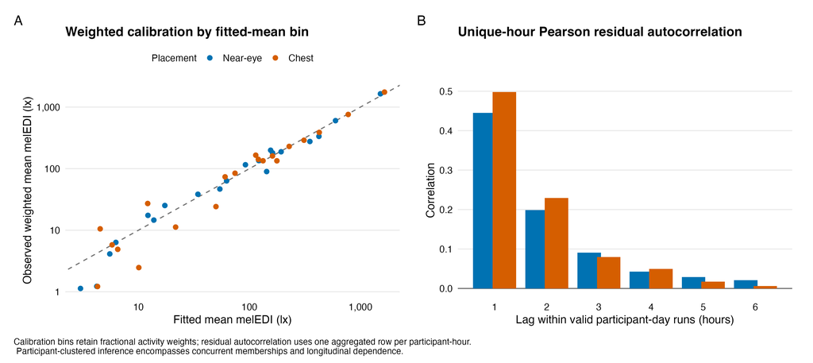

Figure 3: Primary-model calibration and unique-hour residual autocorrelation.

The bounded deletion audit refit each placement after deleting every site and after deleting each of the five highest-score participants. No primary decision changed. Across named contrasts, the maximum relative ratio change in absolute magnitude was 33.3%. This supports decision stability while flagging that some magnitude estimates remain participant- or site-sensitive.

## 7 Prespecified sensitivities and paired/common evidence

Long-row weighting is part of the estimand. Replacing $1/k$ by unit weight changes the question from one contribution per participant-hour to an unweighted selection-level analysis in which multi-select hours contribute more. That run is a sensitivity, not an interchangeable implementation.

Table 12: Exact fitted samples for every prespecified sensitivity.

Sensitivity sample registry

Unweighted-long weighted hours equal long rows by design

| Scenario | Placement | Participants | Participant-days | Unique hours | Long rows | Weighted hours |
| --- | --- | --- | --- | --- | --- | --- |
| exactly_one_category | Near-eye | 126 | 724 | 15,810 | 15,810 | 15,810 |
| exactly_one_category | Chest | 150 | 875 | 19,210 | 19,210 | 19,210 |
| retain_coselected_other | Near-eye | 126 | 724 | 16,526 | 17,333 | 16,526 |
| retain_coselected_other | Chest | 150 | 875 | 20,128 | 21,190 | 20,128 |
| exclude_other_only | Near-eye | 126 | 724 | 16,135 | 16,875 | 16,135 |
| exclude_other_only | Chest | 150 | 875 | 19,497 | 20,440 | 19,497 |
| unweighted_long_rows | Near-eye | 126 | 724 | 16,526 | 17,266 | 17,266 |
| unweighted_long_rows | Chest | 150 | 875 | 20,128 | 21,071 | 21,071 |
| gap_timing_unaware | Near-eye | 126 | 710 | 16,242 | 16,961 | 16,242 |
| gap_timing_unaware | Chest | 150 | 860 | 19,827 | 20,749 | 19,827 |
| paired_common_sample | Near-eye | 110 | 625 | 14,308 | 15,001 | 14,308 |
| paired_common_sample | Chest | 110 | 625 | 14,308 | 15,001 | 14,308 |
| working_power_1_30 | Near-eye | 126 | 724 | 16,526 | 17,266 | 16,526 |
| working_power_1_30 | Chest | 150 | 875 | 20,128 | 21,071 | 20,128 |
| working_power_1_80 | Near-eye | 126 | 724 | 16,526 | 17,266 | 16,526 |
| working_power_1_80 | Chest | 150 | 875 | 20,128 | 21,071 | 20,128 |

Table 13: Stability of the four named-category ratios versus At home.

Sensitivity stability

Stability is descriptive and cannot upgrade the primary claim

| Scenario | Placement | Named contrasts | Stable | Maximum absolute relative change, % | All directions concordant | Primary ratio in sensitivity CI |
| --- | --- | --- | --- | --- | --- | --- |
| exactly_one_category | Near-eye | 4 | 4 | 12.5 | TRUE | TRUE |
| exactly_one_category | Chest | 4 | 4 | 15.3 | TRUE | TRUE |
| exclude_other_only | Near-eye | 4 | 4 | 0.4 | TRUE | TRUE |
| exclude_other_only | Chest | 4 | 4 | 1.0 | TRUE | TRUE |
| gap_timing_unaware | Near-eye | 4 | 4 | 2.6 | TRUE | TRUE |
| gap_timing_unaware | Chest | 4 | 4 | 1.7 | TRUE | TRUE |
| paired_common_sample | Near-eye | 4 | 4 | 4.8 | TRUE | TRUE |
| paired_common_sample | Chest | 4 | 4 | 19.8 | TRUE | TRUE |
| retain_coselected_other | Near-eye | 4 | 4 | 1.0 | TRUE | TRUE |
| retain_coselected_other | Chest | 4 | 4 | 1.3 | TRUE | TRUE |
| unweighted_long_rows | Near-eye | 4 | 4 | 9.6 | TRUE | TRUE |
| unweighted_long_rows | Chest | 4 | 4 | 11.2 | TRUE | TRUE |
| working_power_1_30 | Near-eye | 4 | 4 | 7.3 | TRUE | TRUE |
| working_power_1_30 | Chest | 4 | 4 | 3.9 | TRUE | TRUE |
| working_power_1_80 | Near-eye | 4 | 4 | 14.7 | TRUE | TRUE |
| working_power_1_80 | Chest | 4 | 4 | 14.9 | TRUE | TRUE |

Table 14: Five-named-category robust omnibus results in each prespecified sensitivity.

Sensitivity omnibus tests

Unadjusted diagnostic results; no new confirmatory decision family

| Scenario | Placement | Restrictions | F statistic | Denominator df | Raw p | Status |
| --- | --- | --- | --- | --- | --- | --- |
| exactly_one_category | Near-eye | 4 | 75.54 | 125 | <0.001 | ESTIMABLE |
| exactly_one_category | Chest | 4 | 87.55 | 149 | <0.001 | ESTIMABLE |
| exclude_other_only | Near-eye | 4 | 83.54 | 125 | <0.001 | ESTIMABLE |
| exclude_other_only | Chest | 4 | 92.50 | 149 | <0.001 | ESTIMABLE |
| gap_timing_unaware | Near-eye | 4 | 78.17 | 125 | <0.001 | ESTIMABLE |
| gap_timing_unaware | Chest | 4 | 89.76 | 149 | <0.001 | ESTIMABLE |
| paired_common_sample | Near-eye | 4 | 77.83 | 109 | <0.001 | ESTIMABLE |
| paired_common_sample | Chest | 4 | 69.96 | 109 | <0.001 | ESTIMABLE |
| retain_coselected_other | Near-eye | 4 | 83.02 | 125 | <0.001 | ESTIMABLE |
| retain_coselected_other | Chest | 4 | 92.40 | 149 | <0.001 | ESTIMABLE |
| unweighted_long_rows | Near-eye | 4 | 89.69 | 125 | <0.001 | ESTIMABLE |
| unweighted_long_rows | Chest | 4 | 93.90 | 149 | <0.001 | ESTIMABLE |
| working_power_1_30 | Near-eye | 4 | 78.55 | 125 | <0.001 | ESTIMABLE |
| working_power_1_30 | Chest | 4 | 83.96 | 149 | <0.001 | ESTIMABLE |
| working_power_1_80 | Near-eye | 4 | 91.25 | 125 | <0.001 | ESTIMABLE |
| working_power_1_80 | Chest | 4 | 103.15 | 149 | <0.001 | ESTIMABLE |

All four named contrasts were classified stable in every required sensitivity for both placements. The gap-timing-unaware runs are explicitly named as such; they are not called “gap-aware” or “corrected”. Excluding Other-only hours produces a five-category model, so its five-category omnibus is a sensitivity test and is not relabelled as the secondary six-category omnibus.

The exact paired/common frame contains 110 participants, 625 participant-days, 14,308 unique participant-hours, 15,001 long rows, and 14,308 effective weighted hours at each placement.

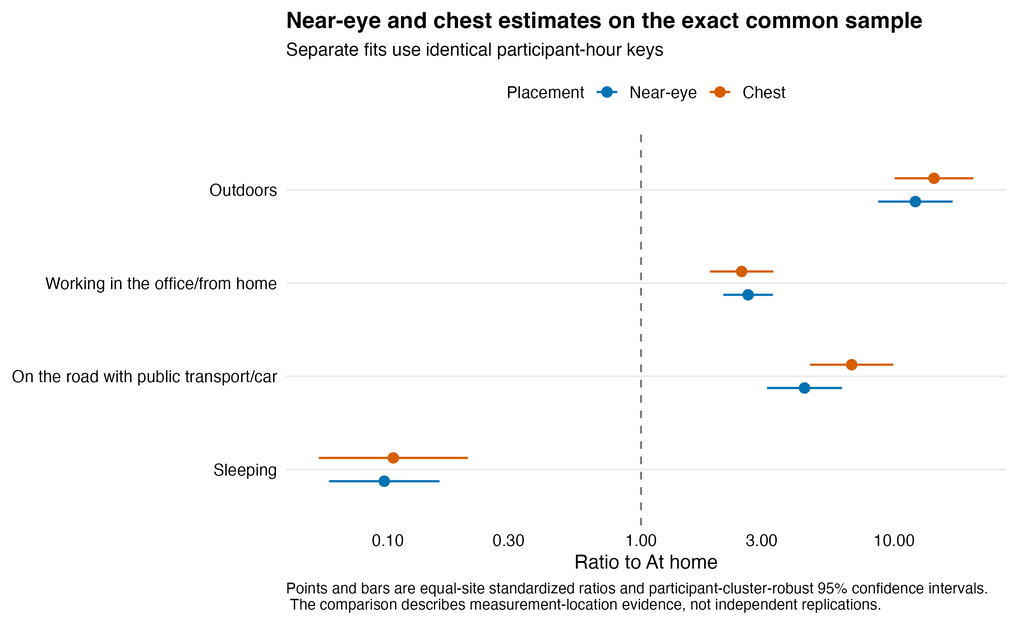

Figure 4: Near-eye and chest named-category ratios versus At home in the exact paired/common sample.

The paired display compares separately fitted named-category ratios on identical participant-hour keys. It is not a within-hour difference model and supplies no unplanned placement-difference p-value.

## 8 Exploratory temporal context

### 8.1 Approved thin-plate `sz` construction

The activity-long temporal model uses the same rows and $1/k$ weights as the mean model. Its global `s(time_hour, bs = "cc", k = 12)` is cyclic. The activity and site `sz` terms omit `xt`, and the synchronized `mgcv` constructor resolves both to the approved thin-plate marginal basis. They are not cyclic; separation at midnight is therefore accepted, quantified, and displayed with open endpoints and no wrap-around line.

Table 15: Constructor-verified temporal basis contract.

Temporal basis contract

Only the global time component is cyclic

| Component | Constructed class | Marginal basis | Cyclic |
| --- | --- | --- | --- |
| global time | cyclic.smooth | cyclic cubic regression spline | TRUE |
| activity deviation | sz.interaction | tp.smooth.spec / tprs.smooth | FALSE |
| site deviation | sz.interaction | tp.smooth.spec / tprs.smooth | FALSE |

Activity-specific runs ensure that concurrent rows with the same timestamp never become lag-one neighbours. A run restarts at participant-day, activity, DST repeated-hour, non-consecutive-hour, or gap boundaries. The no-activity comparator uses the identical long frame, weights, and run construction.

Table 16: Predeclared temporal retention decision.

Temporal adequacy and added-context gate

AIC is used only for this exploratory comparator

| Placement | Minimum k-index | Activity-model AIC | No-activity AIC | Delta AIC | Activity deviance explained | Comparator deviance explained | Residual lag 1 | Sparse clock/category cells | Max activity midnight ratio | Max site midnight ratio | Retained | Assessment |
| --- | --- | --- | --- | --- | --- | --- | --- | --- | --- | --- | --- | --- |
| Near-eye | 0.872 | 130,763.1 | 133,978.0 | −3,215.0 | 0.848 | 0.818 | 0.176 | 41 | 4.61 | 14.48 | TRUE | ACCEPTABLE WITH LIMITATION |
| Chest | 0.863 | 162,679.4 | 167,663.0 | −4,983.6 | 0.832 | 0.795 | 0.167 | 40 | 9.05 | 1.53 | TRUE | ACCEPTABLE WITH LIMITATION |

Near eye, the activity model improves AIC by 3,215 and explains 84.8% versus 81.8% deviance; chest improves AIC by 4,984 and explains 83.2% versus 79.5%. The minimum finite k-indices are 0.872 and 0.863. Final residual lag-one correlations are 0.176 and 0.167. Both models therefore add context and are retained **acceptable with limitation**. The 41 near-eye and 40 chest locally sparse clock/category cells, residual dependence, and potentially large thin-plate midnight separation remain explicit limitations. Both retained activity-model passes completed without warnings. The chest no-activity comparator’s preliminary zero-rho fit warned that its algorithm did not converge, but its final fixed-rho fit converged without a warning; the comparator is used only for this exploratory added-context check.

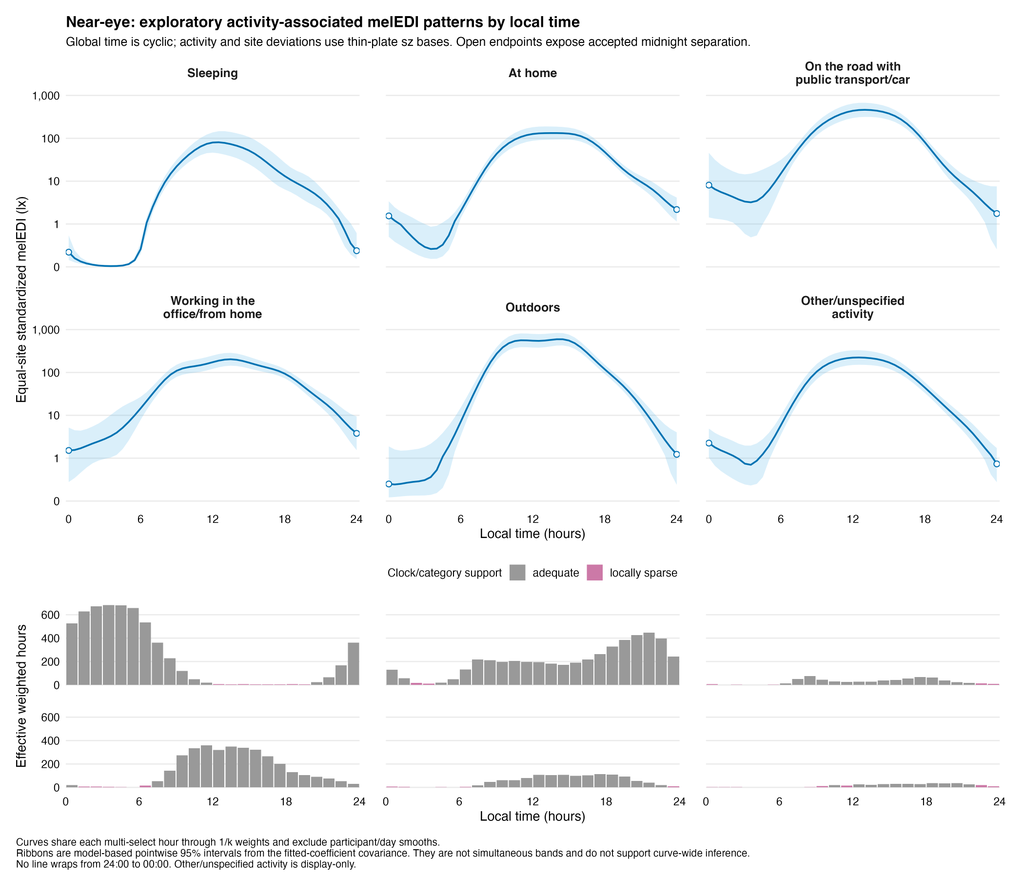

Figure 5: Exploratory near-eye activity-associated time-of-day means with model-based pointwise 95% intervals and weighted support.

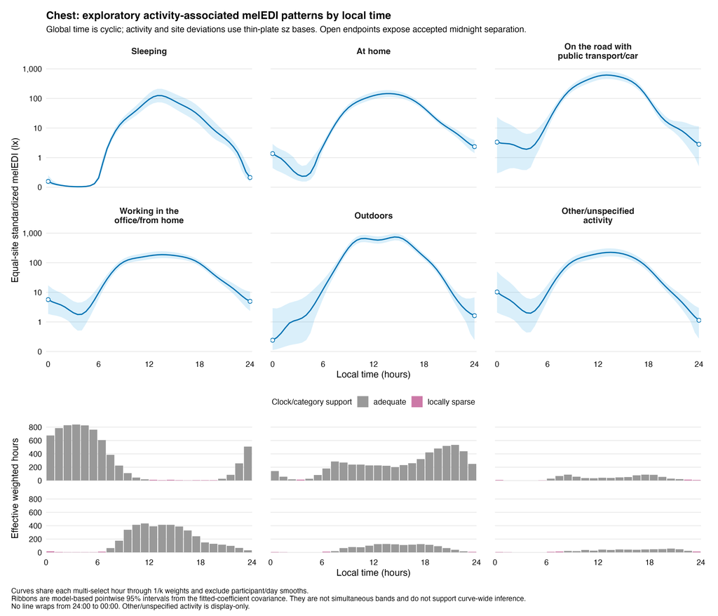

Figure 6: Exploratory chest activity-associated time-of-day means with model-based pointwise 95% intervals and weighted support.

Approximate smooth p-values are not used as the H04 primary test. The temporal curves are descriptive exploratory context and cannot support a causal or “significant period” claim.

### 8.2 H03-aligned pointwise uncertainty

For each time-by-activity curve, the fitted population design rows are averaged equally across the observed sites on the log-mean scale after setting the participant and participant-day smooth contributions to zero. If $\bar{\boldsymbol{x}}_{tc}$ is that design row, $\widehat{\boldsymbol\beta}$ is the accepted final GAMM’s coefficient vector, and $\widehat{\boldsymbol V}_{\beta}$ is its fitted-coefficient covariance, the reported interval is

$$\exp\left\{
\bar{\boldsymbol{x}}_{tc}^{\mathsf T}\widehat{\boldsymbol\beta}
\mathbin{\pm}
1.96\sqrt{
\bar{\boldsymbol{x}}_{tc}^{\mathsf T}
\widehat{\boldsymbol V}_{\beta}
\bar{\boldsymbol{x}}_{tc}
}
\right\}.$$

This is the H03 implementation: `stats::vcov(fit, unconditional = TRUE)` with the fitted `Vp` matrix only as an error fallback, followed by one back-transformation. It conditions on the fitted smoothing structure. The ribbons are pointwise 95% intervals, not simultaneous bands, and no time-specific hypothesis test is performed. This permits no curve-wide inference.

Table 17: H03-aligned temporal uncertainty contract.

Temporal uncertainty

Model-based pointwise intervals; no bootstrap or simulation

| Placement | Covariance source | Interval | Resampling replicates | Inferential boundary |
| --- | --- | --- | --- | --- |
| Near-eye | stats::vcov(fit, unconditional = TRUE) | Pointwise 95% (critical value 1.96) | 0 | No simultaneous band; no time-specific or curve-wide inference |
| Chest | stats::vcov(fit, unconditional = TRUE) | Pointwise 95% (critical value 1.96) | 0 | No simultaneous band; no time-specific or curve-wide inference |

**NoteSuperseded bootstrap pilot preserved only for provenance**

The bootstrap pilot was stopped before its target after the author selected the H03 uncertainty implementation. Its 35 completed checkpoint files are retained in the H04 model-artifact directory so the attempted computation remains auditable. They are excluded from H04 estimates, intervals, figures, tests, and scientific claims. No production bootstrap is required or authorized.

## 9 V0 reconstruction and comparison

V0 used a unit-weight long-row analysis, removed Other, could retain duplicate collapsed outdoor rows, and fit a Tweedie mixed model with the joint site-by-activity interaction. Its site-only versus full likelihood-ratio test jointly added four activity coefficients and all supported site interactions; it is not a test of the repaired H04 five-category equality hypothesis.

Table 18: Frozen V0, current-input V0 bridge, and repaired H04 analytical denominators.

V0 denominator and test comparison

The current-input bridge is not the frozen submitted result

| Placement | Implementation | Long rows | Unique participant-hours | Effective weighted hours | Categories | Test definition |
| --- | --- | --- | --- | --- | --- | --- |
| Near-eye | Frozen V0 model | 16,801 | — | 16,801 | 5 | site-only versus category-plus-site-interaction likelihood-ratio test |
| Near-eye | V0 bridge on current normalized inputs | 16,925 | 16,135 | 16,925 | 5 | site-only versus category-plus-site-interaction likelihood-ratio test |
| Near-eye | Approved repaired H04 | 17,266 | 16,526 | 16,526 | 6 | four-restriction participant-cluster robust F test for equality of five named categories; Other unrestricted |
| Chest | Frozen V0 model | 20,327 | — | 20,327 | 5 | site-only versus category-plus-site-interaction likelihood-ratio test |
| Chest | V0 bridge on current normalized inputs | 20,489 | 19,497 | 20,489 | 5 | site-only versus category-plus-site-interaction likelihood-ratio test |
| Chest | Approved repaired H04 | 21,071 | 20,128 | 20,128 | 6 | four-restriction participant-cluster robust F test for equality of five named categories; Other unrestricted |

The frozen near-eye and chest V0 records contain 16,801 and 20,327 model rows. The bridge rebuilt on current normalized inputs contains 16,925 rows/16,135 unique hours near eye and 20,489 rows/19,497 unique hours at chest. These are not the frozen V0 denominators and are kept separate. The repaired H04 models contain more long rows because Other-only hours remain, but their effective weighted hours equal unique participant-hours by construction.

Table 19: Current-input reconstruction of V0’s joint category-plus-interaction likelihood-ratio test.

V0 bridge joint tests

Comparator only; no repaired-H04 decision or significance styling

| Placement | Restrictions added | Likelihood-ratio chi-square | Raw p | Interpretation |
| --- | --- | --- | --- | --- |
| Near-eye | 36 | 10,034.55 | <0.001 | jointly adds activity main effects and site interactions; not the repaired H04-F1 primary test |
| Chest | 32 | 11,680.45 | <0.001 | jointly adds activity main effects and site interactions; not the repaired H04-F1 primary test |

Table 20: Recognizable V0 category-versus-home ratios rebuilt on current normalized inputs.

V0 bridge ratios

Current-input reconstruction; not the approved estimand or inference

| Placement | V0 contrast | Ratio (95% model-based CI) | Role |
| --- | --- | --- | --- |
| Near-eye | outdoor / home | 8.744 (7.784 to 9.824) | V0 bridge only; no repaired-H04 decision |
| Near-eye | road_vehicle / home | 4.812 (4.266 to 5.428) | V0 bridge only; no repaired-H04 decision |
| Near-eye | sleep / home | 0.043 (0.039 to 0.047) | V0 bridge only; no repaired-H04 decision |
| Near-eye | working_indoor / home | 3.211 (2.976 to 3.464) | V0 bridge only; no repaired-H04 decision |
| Chest | outdoor / home | 10.155 (9.259 to 11.138) | V0 bridge only; no repaired-H04 decision |
| Chest | road_vehicle / home | 6.529 (5.814 to 7.331) | V0 bridge only; no repaired-H04 decision |
| Chest | sleep / home | 0.043 (0.040 to 0.047) | V0 bridge only; no repaired-H04 decision |
| Chest | working_indoor / home | 3.121 (2.892 to 3.369) | V0 bridge only; no repaired-H04 decision |

The reconstructed V0 joint tests and familiar ratios are reported only to explain why the repaired estimates differ. They do not inherit V0’s p-values, significance labels, or causal-sounding wording.

## 10 Reproducibility, source data, and reporting limits

All scientific transformations, fits, diagnostics, estimates, and displays were generated with R 4.6.1 and the synchronized project library. No package was installed or updated. Input identities were hash-verified before fitting. The model objects, exact frames, restrictions, diagnostics, source-data CSVs, figures, checkpointed pilot replicates, and software versions are H04-scoped artifacts.

Table 21: R and consequential package versions used for H04 Stage 2.

Software environment

| Component | Version |
| --- | --- |
| R | 4.6.1 |
| R package: dplyr | 1.2.1 |
| R package: tidyr | 1.3.2 |
| R package: purrr | 1.2.2 |
| R package: tibble | 3.3.1 |
| R package: readr | 2.2.0 |
| R package: digest | 0.6.39 |
| R package: openssl | 2.4.2 |
| R package: statmod | 1.5.2 |
| R package: sandwich | 3.1.1 |
| R package: glmmTMB | 1.1.14 |
| R package: emmeans | 2.0.3 |
| R package: ggplot2 | 4.0.3 |
| R package: scales | 1.4.0 |
| R package: LightLogR | 0.10.3 |
| R package: patchwork | 1.3.2 |
| R package: gt | 1.3.0 |

Durable figure/source pairs are:

- `H04_primary_category_estimates.*` with `H04_primary_category_figure.csv`;
- `H04_site_activity_estimates.*` with `H04_site_activity_figure.csv`;
- `H04_paired_placement_comparison.*` with `H04_paired_placement_figure.csv`;
- `H04_primary_diagnostics.*` with the calibration and ACF CSVs;
- `H04_temporal_near_eye.*` and `H04_temporal_chest.*` with exact placement-specific curve and weighted-support CSVs; and
- the temporal uncertainty contract and bootstrap-supersession registry, which make the pointwise-only reporting boundary and the unused pilot evidence explicit.

The primary inference is population-average and observational. Fractional membership is a transparent allocation rule, not proof that the labels fully capture behaviour. Self-report timing and category ambiguity remain. Other is heterogeneous and non-substantive. Equal-site standardization describes the observed site set and does not generalize automatically to other populations. Robust covariance protects the registered mean-model tests against arbitrary within-participant correlation under the working mean model; it does not cure mean misspecification, sparse cells, or influential clusters.

## 11 Stage 2 stop

The Stage 2 implementation is complete. No Stage 3 reader report has been created. The following decisions require explicit author approval:

Table 22: Decisions requested at the H04 Stage 2 gate.

H04 Stage 2 gate

Stage 3 is not authorized by this report

| gate_id | decision_requested |
| --- | --- |
| H04-S2-G1 | Approve the Stage 2 primary result and claim scope: an observational association between reported activity category and one-hour melEDI, with Other excluded from scientific claims. |
| H04-S2-G2 | Approve the separate five-named-category site-heterogeneity result and its support-limited exploratory presentation. |
| H04-S2-G3 | Approve the primary diagnostics as acceptable with limitation and retain the full sensitivity and influence qualifications. |
| H04-S2-G4 | Approve the exploratory temporal presentation with H03-aligned model-based pointwise 95% intervals, no simultaneous bands or curve-wide inference, and the stated residual, support, and midnight limita… |
| H04-S2-G5 | Authorize Stage 3 as a standalone reader-facing H04 report with no V0 or construction-history language. |

**STOP.** Await explicit author approval. Do not create the Stage 3 reader report or begin Stage 4 from this document.